# Demographics Impact on FordGoBikes Subscriptions

## Investigation Overview

In this investigation, I wanted to look at the demographics of FordGoBikes users that could be used to inform target audience for subscriptions. The main focus of this analysis was on gender, age, location, and days of the week rented.

## Dataset Overview

The data consisted of approxiamtely 174,952 (clean) entries all belonging to February of 2019. In total this set contains 16 features/columns (duration, start time, end time, start station id, start station name, start station latitude, start station longitude, end station id, end station name, end station latitude, end station longitude, bike id, user type, member birth year, member gender, bike share for all). There is a mix between numeric and categorical variables.

### Distribution of users based on gender:

The majority of FordGoUsers are males, making up for nearly 75% of total users. Females make up for 23.3% and other genders for 2.1%. This data is visualized in a pie chart below.

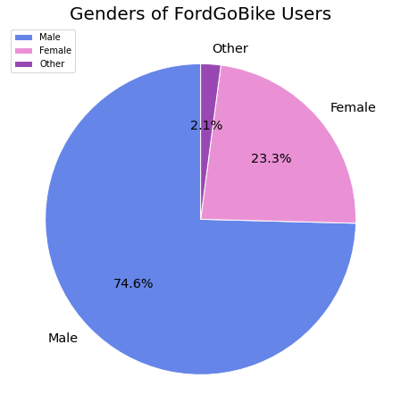

### Distribution of users based on age:

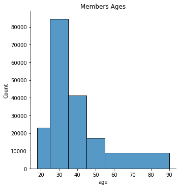

### Distribution of users based on subscription and gender:

9.5% of FordGoBike users in February of 2019 were subscribers. 75% of subscribers were male, followed by a 22.8% females and 2% for other genders. This distribution is nearly identical to that of the overall users.

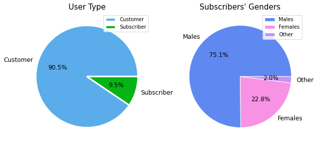

### Most popular stations and their user type:

The most popular stations overall saw an overwhelming majority of subscribers over casual users for both start and return station.

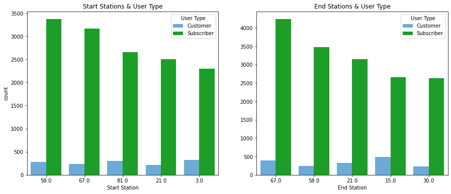

### Weekdays and time influence on rentals:

Most bikes are rented on Thursday mornings. Overall, the most popular time to rent FordGoBikes was between 8-10 AM followed by 4-6 PM as shown in the heatmap below.

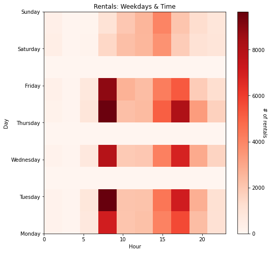

### Distribution based on duration, gender, and weekday:

Overall, males tend to use bikes for a shorter period of time than females and other genders with an average of <15 minutes. Other genders tend to have the highest duration, usually over 15 minutes. While weekends are not the most popular time to rent, they are the days in which all genders tend to bike for longer.

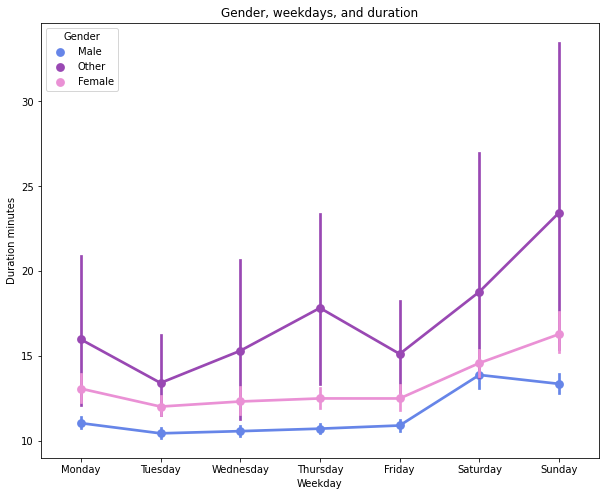